# ts_3

Soumarya Basak

2022-06-21

# Library

```r
library(tseries)
library(forecast)
```

# Data

```r
Y1 = c(79.35,75.78,86.32,72.60,74.86,83.81,79.80,62.41,85.41,
       83.11,84.21,89.70)
Y2 = c(78.64,77.42,89.86,81.27,78.68,89.51,83.67,69.80,91.09,
       89.43,91.04,92.87)
Y3 = c(81.87,85.36,92.98,81.09,85.64,91.14,83.46,66.37,93.34,
       85.93,86.81,93.30)
Y4 = c(81.59,81.77,91.24,79.45,86.99,96.60,97.99,79.13,103.56,
       100.89,99.40,111.80)
Y5 = c(95.30,97.77,116.23,100.98,104.70,114.64,107.62,96.12,123.50,
       116.12,116.86,128.61)
Y6 = c(100.56,103.05,119.06,92.46,98.75,111.14,96.13,79.72,102.07,
       96.18,101.26,109.85)
Y7 = c(89.52,89.27,104.35,87.05,89.33,102.20,88.13,75.68,99.48,96.40,
       96.16,101.00)
Y8 = c(89.34,86.91,98.90,85.54,85.25,101.14,91.80,76.98,104.33,99.72,
       101.06,109.00)
Y9 = c(89.88,92.27,105.11,91.50,92.56,104.35,96.21,79.58,105.43,99.18,
       99.77,113.55)
Y10 = c(91.65,90.56,105.52,92.18,91.22,109.04,99.26,83.36,110.80,104.95,
        107.07,114.40)
Y11 = c(99.16,99.86,116.14,103.48,107.07,119.32,107.94,90.59,121.80,117.11,
        113.71,120.37)
Y12 = c(103.93,104.10,125.72,104.70,108.45,123.11,108.89,94.07,121.88,116.81,
        115.87,127.14)
Y13 = c(109.45,105.23,121.32,108.78,103.20,117.93,103.76,89.27,109.50,104.02,100.12,101.18)
Y14 = c(77.38,75.19,86.40,74.13,74.10,85.61,79.90,65.36,88.09,84.60,
        88.09,102.52)
Y15 = c(79.28,78.74,94.62,84.66,85.20,103.94,89.87,78.14,96.50,94.68,101.77,
        103.48)
Y16 = c(92.57,89.16,104.48,89.45,93.40,102.90,93.77,77.58,95.04,91.77,93.37,98.34)
Y17 = c(86.44,85.04,97.80)

d = c(Y1,Y2,Y3,Y4,Y5,Y6,Y7,Y8,Y9,Y10,Y11,Y12,Y13,Y14,Y15,Y16,Y17)

#The time series
ts3 = ts(d, start = c(1990,1), frequency = 12)
```

# Analysis

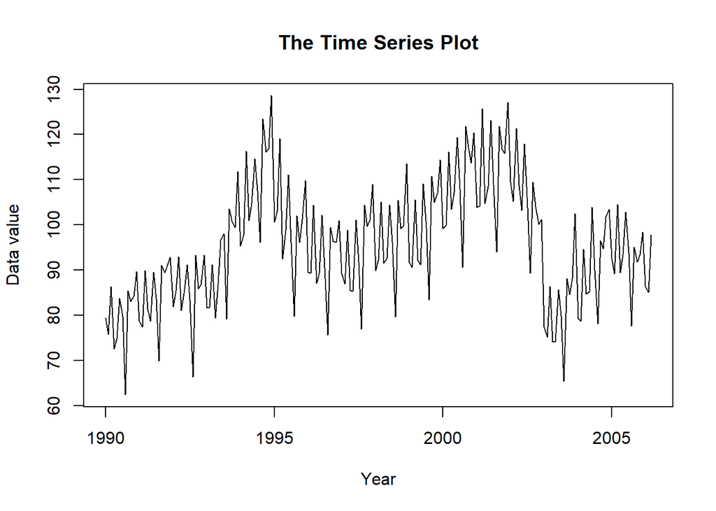

```r
plot(ts3, main="The Time Series Plot", xlab="Year",ylab="Data value")
```

The plot indicates that there is a clear trend and seasonality in the data set. So we need to remove those to further fit a ARIMA model.

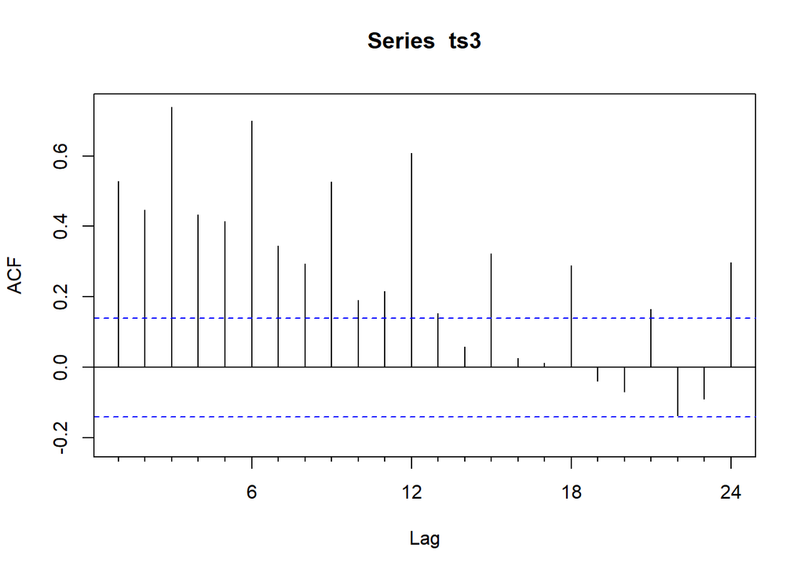

```r
Acf(ts3)
```

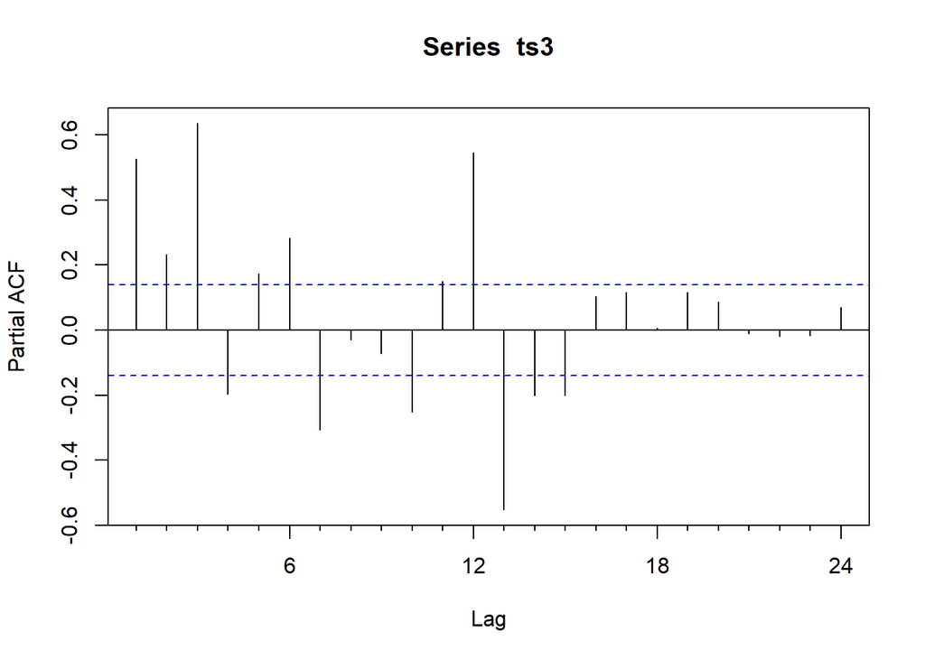

```r
Pacf(ts3)
```

The ACF and PACF plot shows that there is also a rend and seasonality

## Differencing for trend

```r
# 1st difference
d_1<- diff(ts3, 1)
adf.test(d_1)
```

```
##
##  Augmented Dickey-Fuller Test
##
## data:  d_1
## Dickey-Fuller = -6.5358, Lag order = 5, p-value = 0.01
## alternative hypothesis: stationary
```

SO, the first order difference make the time series stationary,

Lets check the Acf plot

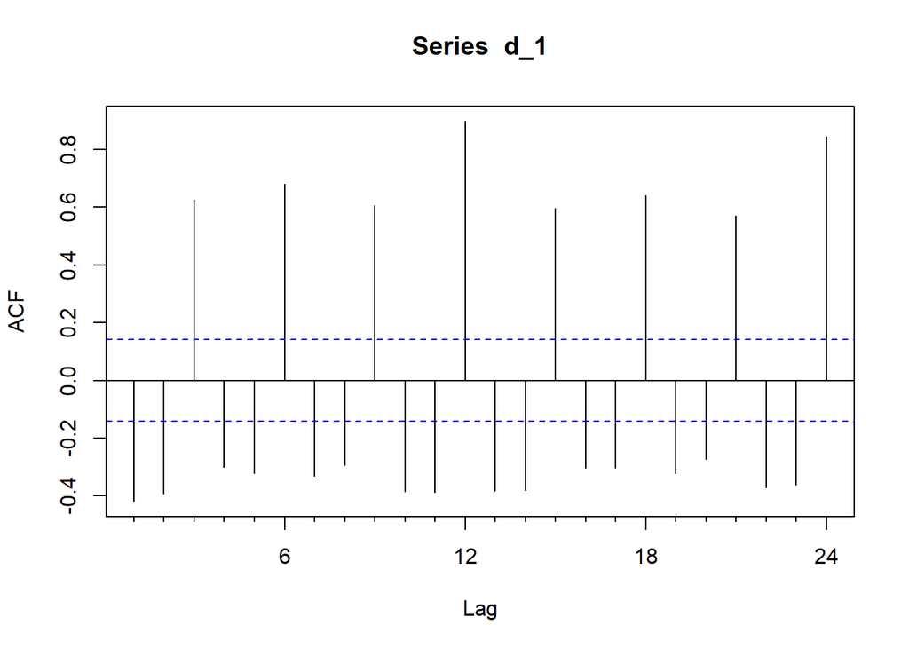

```r
Acf(d_1)
```

The acf plot indicats that the series becomes stationary in trend.

**Lets zoom plot of the series**

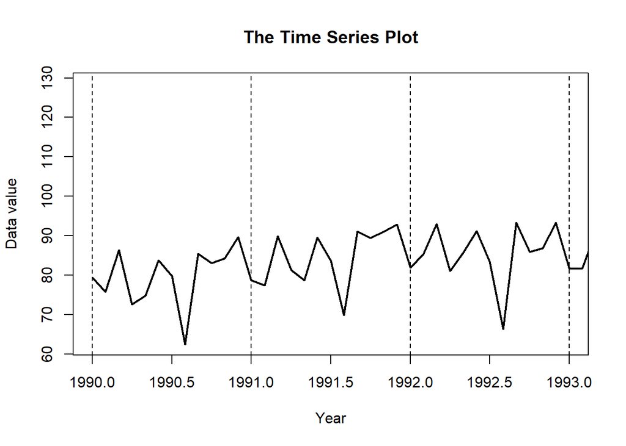

```r
plot(ts3, main="The Time Series Plot", xlab="Year",ylab="Data value", xlim=c(1990,1993), lwd=2)
abline(v=c(1990,1991,1992,1993), lty=2)
```

From the above plot we can see there is a monthly seasonality, in the data, so the priod is of `s=12`.

```r
d_12<- diff(ts3, 12)
adf.test(d_12)
```

```
##
##  Augmented Dickey-Fuller Test
##
## data:  d_12
## Dickey-Fuller = -3.6811, Lag order = 5, p-value = 0.02751
## alternative hypothesis: stationary
```

The p value the less than 0.05, so the first order seasonal differencing make the series deseasoanlized.

**d=1, D=1**

### To find `p` and `q`

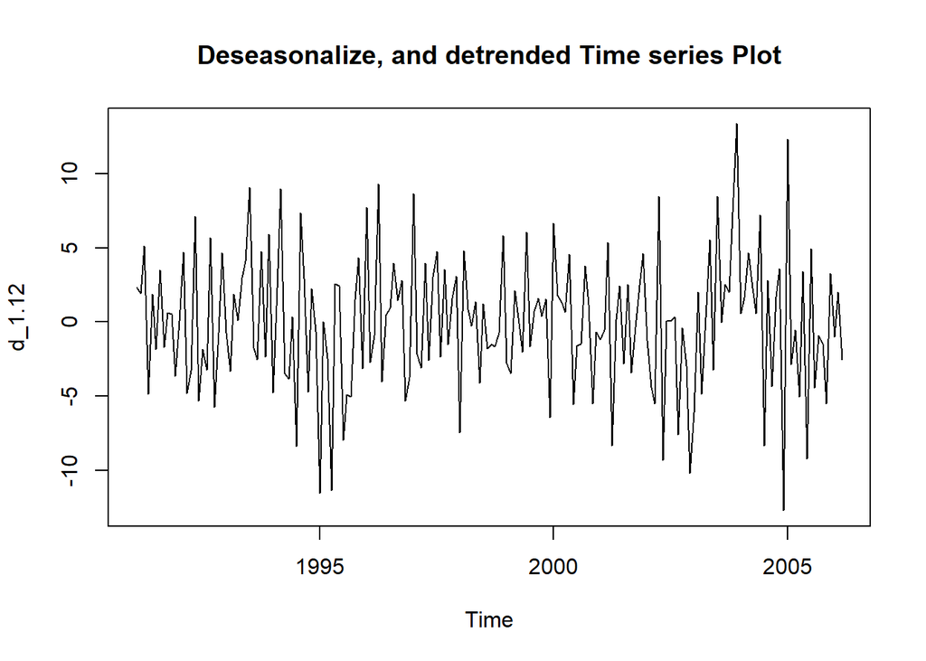

```r
d_1.12<- diff(diff(ts3,12),1)
plot(d_1.12, main="Deseasonalize, and detrended Time series Plot")
```

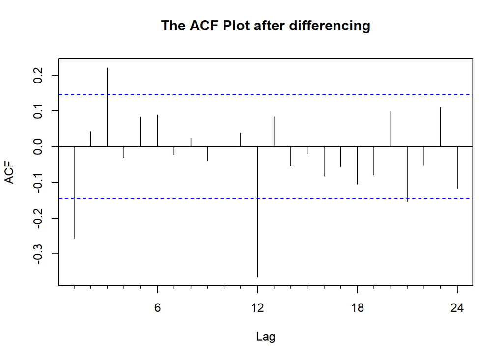

```r
Acf(d_1.12, main="The ACF Plot after differencing")
```

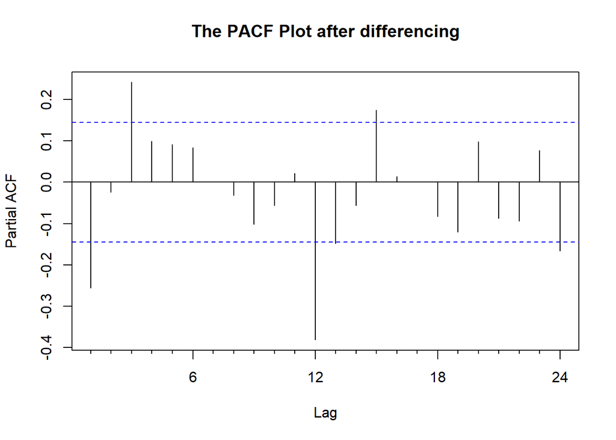

```r
Pacf(d_1.12, main="The PACF Plot after differencing")
```

From the Acf and Pacf plot it is clear that, for the trend `p=1 or 3` and `q=1 or 3` and for the seasonal part `P=1 to 4` and `Q=1`

Note that `D=1` and `d=1`

### Lets fit the ARIMA model

We will fit **alternative Arima** Model and choose that one which gives least AIC

```r
library(sarima)
auto.arima(ts3, approximation = FALSE, stepwise = FALSE)
```

```
## Series: ts3
## ARIMA(4,0,0)(0,1,1)[12]
##
## Coefficients:
##          ar1     ar2     ar3      ar4     sma1
##       0.6577  0.2800  0.3390  -0.3181  -0.8438
## s.e.  0.0698  0.0817  0.0825   0.0701   0.0772
##
## sigma^2 = 11.27:  log likelihood = -486.94
## AIC=985.89   AICc=986.36   BIC=1005.14
```

```r
#library(bayesforecast)
#auto.sarima(ts3, chains = 4)
```

```r
# Generating orders

p<- c(0,1,2,3)
q= c(0,1,2,3)
P<- c(0,1,2,3)
Q<- c(1)

#---------------------------- Alternative models ----------------------

for (i in 1:(length(p))) {
  for (j in 1:(length(q))) {
    for (a in 1:(length(P))) {
      for (b in 1:(length(Q))) {
        model<- Arima(ts3, order = c(P[i],1,q[j]), seasonal = list(order=c(P[a],1,Q[b]), period=12) )
        print(paste("For the model: Arima:",p[i],"1",q[j],P[a],"1",Q[1],"AIC:",model$aic))
      }

    }

  }

}
```

```
## [1] "For the model: Arima: 0 1 0 0 1 1 AIC: 1017.37970774659"
## [1] "For the model: Arima: 0 1 0 1 1 1 AIC: 1013.24362392336"
## [1] "For the model: Arima: 0 1 0 2 1 1 AIC: 1015.08406964464"
## [1] "For the model: Arima: 0 1 0 3 1 1 AIC: 1016.98054987011"
## [1] "For the model: Arima: 0 1 1 0 1 1 AIC: 1000.58811735447"
## [1] "For the model: Arima: 0 1 1 1 1 1 AIC: 998.433652250505"
## [1] "For the model: Arima: 0 1 1 2 1 1 AIC: 1000.16237824323"
## [1] "For the model: Arima: 0 1 1 3 1 1 AIC: 1002.05878993876"
## [1] "For the model: Arima: 0 1 2 0 1 1 AIC: 995.373951875234"
## [1] "For the model: Arima: 0 1 2 1 1 1 AIC: 993.971053474117"
## [1] "For the model: Arima: 0 1 2 2 1 1 AIC: 995.908048583606"
## [1] "For the model: Arima: 0 1 2 3 1 1 AIC: 997.874218899317"
## [1] "For the model: Arima: 0 1 3 0 1 1 AIC: 987.87662089181"
## [1] "For the model: Arima: 0 1 3 1 1 1 AIC: 987.344151003715"
## [1] "For the model: Arima: 0 1 3 2 1 1 AIC: 989.245559743626"
```

[output cut: 49 more lines]

```r
#----------------------------------------------------------------------
```

From the list of above models, we find that, the model `SARIMA( 3 ,1 ,1 ,0 ,1 ,1)` has least AIC.

```r
#---------------------SARIMA( 3 ,1 ,1 ,0 ,1 ,1)-------------------
s_model<- Arima(ts3,order = c(3,1,1), seasonal = list(order=c(0,1,1), period=12))
summary(s_model)
```

```
## Series: ts3
## ARIMA(3,1,1)(0,1,1)[12]
##
## Coefficients:
##          ar1     ar2     ar3      ma1     sma1
##       0.0653  0.1066  0.3595  -0.4381  -0.8425
## s.e.  0.2062  0.0934  0.0701   0.2223   0.0753
##
## sigma^2 = 11.4:  log likelihood = -484.8
## AIC=981.6   AICc=982.08   BIC=1000.83
##
## Training set error measures:
##                       ME     RMSE      MAE         MPE    MAPE      MASE
## Training set -0.03257112 3.217377 2.409824 -0.07150537 2.51924 0.2946349
##                      ACF1
## Training set -0.001187516
```

```r
#------------- Test for randomness of residuals-----------

Box.test(resid(s_model), lag = (length(ts3)-1) , type = "Ljung-Box" )
```

```
##
##  Box-Ljung test
##
## data:  resid(s_model)
## X-squared = 156.22, df = 194, p-value = 0.9785
```

The p value of the test indicates that we have to accept the fact that the residuals of the models and random so, can’t be further modeled.\ **So we stick to this model for our analysis purpose**

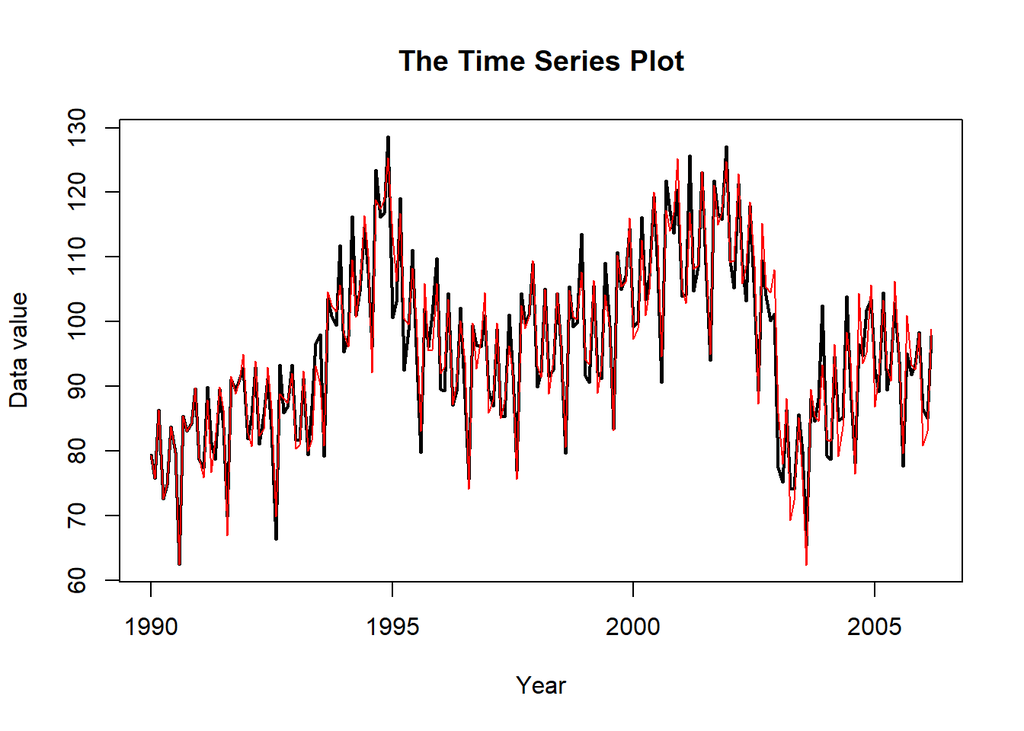

```r
plot(ts3, main="The Time Series Plot", xlab="Year",ylab="Data value", lwd=2)
lines(fitted(s_model), col="red")
```

## Forecast

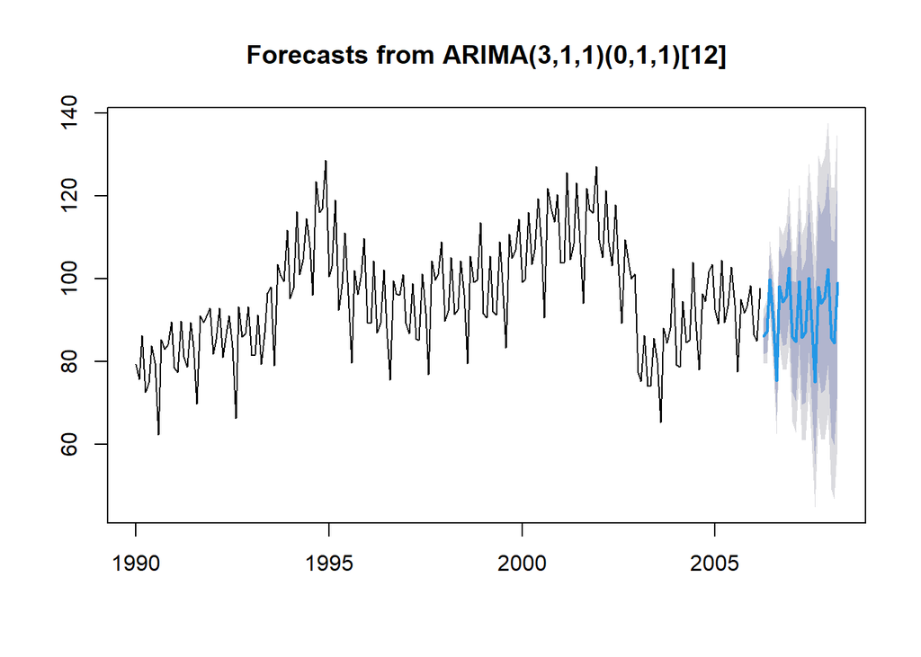

```r
plot(forecast(s_model))
```